# Missing Data practical II

Valentijn de Jong and Thomas Debray

November 2020

For this computer practical, you need to have access to the free software [R](https://www.r-project.org/) and [RStudio](https://www.rstudio.com/products/rstudio/) (desktop edition). Make sure you install `R` first. Although it is not necessary to have any experience in `R` programming for this practical, a tutorial is available [online](http://tryr.codeschool.com/).

Alternatively, you can use RStudio in the cloud, which only requires access to an internet browser such as Google Chrome. RStudio Cloud is currently free to use. Please visit https://rstudio.cloud/ and choose “Get Started”.

This practical was developed using R version 4.0.2. Open RStudio and verify if your installed version is up-to-date:

```r
R.Version()$version.string
```

Please note that if your R version is older than 4.0.2, you may not be able to install the latest updates of mice and many other packages. As a result, some functions may not work properly or at all.

## Introduction

You are an epidemiology consultant. You are asked to participate in a cohort study on annual influenza vaccine effectiveness. The aim of the study is to assess whether annual influenza vaccination reduces the risk of hospitalisation. The data consist of observations on eligible subjects who did, or did not, receive the annual influenza vaccine. The endpoint in this study is hospitalisation during the influenza epidemic period. Note that the vaccine was not randomly allocated; rather vaccination status may depend on characteristics of the participants in the study.

| Variable | Description | Values | Meaning |
| --- | --- | --- | --- |
| vacc | Influenza vaccination | 0 | Unvaccinated |
|  |  | 1 | Vaccinated |
| age | Age | Continuous | Years |
| sex | Sex | 0 | Male |
|  |  | 1 | Female |
| cvd | Cardiovascular disease | 0 | Absent |
|  |  | 1 | Present |
| pulm | Pulmonary disease | 0 | Absent |
|  |  | 1 | Present |
| DM | Diabetus mellitus | 0 | Absent |
|  |  | 1 | Present |
| contact | Number of GP contacts | Discrete | Count |
| hosp | Hospitalisation status | 0 | No hospitalisation |
|  |  | 1 | Hospitalisation |

## Preparation

The research question you will address here is whether influenza vaccination affects hospitalisation. As vaccination was not randomized, confounder adjustment is necessary. To address this effect, we here will fit the following regression model:

```r
Formula <- formula(hosp ~ vacc + DM + cvd + pulm + I(log(contact)) + age + sex)
```

Let’s first install and load some relevant R packages

```r
install.packages(c("VIM", "mnormt", "mice"))

library("VIM")
library("mnormt")
library("mice")
```

Please make sure you have mice version 3.11.0:

```r
packageVersion("mice")
```

```
## [1] '3.11.0'
```

We can load the data from the cohort study on annual influenza vaccine effectiveness as follows:

```r
load("miss.data.uni.RData") # if the data is in your working directory
load(file.choose()) # if it is not
```

Before undertaking any analysis, we initialize a random seed so you can compare results with peers.

```r
set.seed(111111)
```

**Question 1.** How many observations do we have? What percentage observations is missing, on each variable?

```r
summary(miss.data.uni)
```

```
##       vacc             age              sex              cvd
##  Min.   :0.0000   Min.   : 65.00   Min.   :0.0000   Min.   :0.000
##  1st Qu.:0.0000   1st Qu.: 70.00   1st Qu.:0.0000   1st Qu.:0.000
##  Median :1.0000   Median : 75.00   Median :1.0000   Median :0.000
##  Mean   :0.7404   Mean   : 75.65   Mean   :0.6191   Mean   :0.467
##  3rd Qu.:1.0000   3rd Qu.: 80.00   3rd Qu.:1.0000   3rd Qu.:1.000
##  Max.   :1.0000   Max.   :104.00   Max.   :1.0000   Max.   :1.000
##                                                     NA's   :9793
##       pulm              DM             contact            hosp
##  Min.   :0.0000   Min.   :0.00000   Min.   :  2.00   Min.   :0.00000
##  1st Qu.:0.0000   1st Qu.:0.00000   1st Qu.:  7.00   1st Qu.:0.00000
##  Median :0.0000   Median :0.00000   Median : 12.00   Median :0.00000
##  Mean   :0.1234   Mean   :0.06545   Mean   : 14.75   Mean   :0.00635
##  3rd Qu.:0.0000   3rd Qu.:0.00000   3rd Qu.: 20.00   3rd Qu.:0.00000
##  Max.   :1.0000   Max.   :1.00000   Max.   :146.00   Max.   :1.00000
##
```

```r
str(miss.data.uni)
```

```
## 'data.frame':    40000 obs. of  8 variables:
##  $ vacc   : int  1 1 1 1 1 1 1 1 1 1 ...
##  $ age    : int  66 73 75 76 77 78 80 81 66 67 ...
##  $ sex    : int  0 1 1 1 1 1 1 1 0 0 ...
##  $ cvd    : int  NA 1 1 1 1 1 1 NA 0 0 ...
##  $ pulm   : int  1 0 0 0 0 0 0 0 0 0 ...
##  $ DM     : int  0 0 0 0 0 0 0 0 0 0 ...
##  $ contact: int  27 4 8 7 7 5 9 17 10 13 ...
##  $ hosp   : int  0 0 0 0 0 0 0 0 0 0 ...
```

```r
pctMissing <- function(x) round(colMeans(is.na(x)) * 100, 2)
pct.missing <- pctMissing(miss.data.uni)
pct.missing
```

```
##    vacc     age     sex     cvd    pulm      DM contact    hosp
##    0.00    0.00    0.00   24.48    0.00    0.00    0.00    0.00
```

```r
miss.cvd <- is.na(miss.data.uni$cvd) # Indicators of missing information on cvd.
```

*Answer: We have a total of 40000 observations. The missingness on the variables varies from 0% to 24.48%. On average, 3.06% of all variables are missing.*

We can inspect the presence of missing values more thoroughly using `aggr()`:

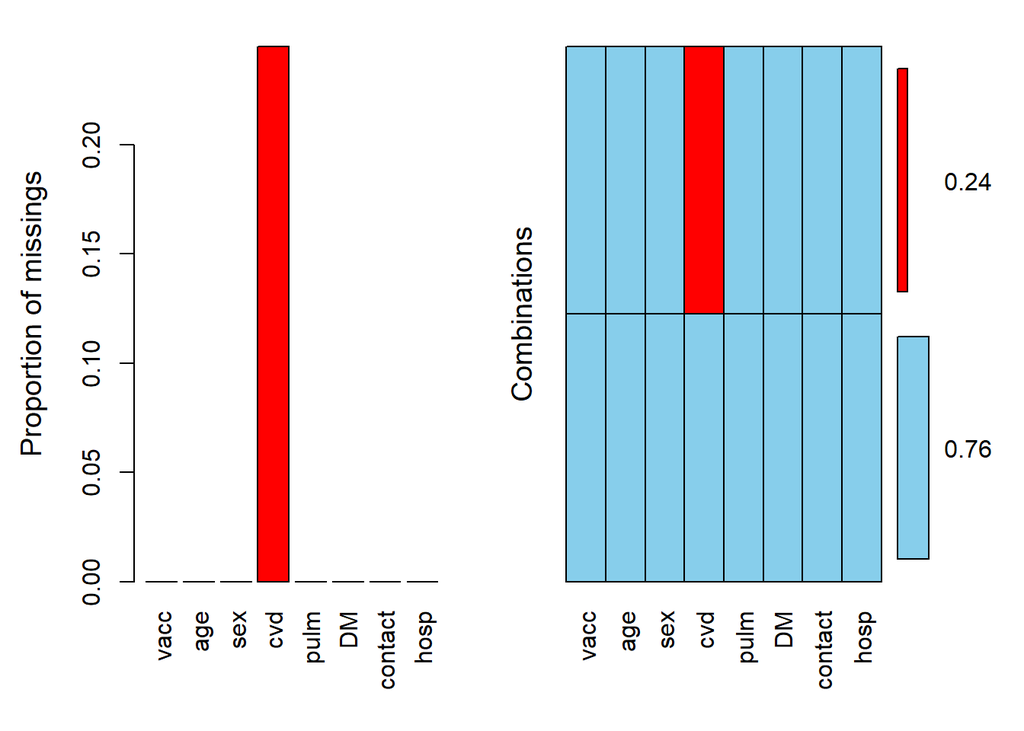

```r
aggr(miss.data.uni, numbers = TRUE)
```

## Simple methods

We will now pursue several strategies for handling the missing values for `cvd` in our dataset. We will start the analysis with three simple methods:

- 1. Complete case analysis (CCA),
  - 2. Dropping predictors with missing values,
  - 3. Mean imputation.

For all imputation methods, we will store the estimated regression coefficient for influenza vaccination and the corresponding standard error.

```r
results.vacc <- data.frame("b" = numeric(), "se" = numeric())
```

### A. Complete case analysis (CCA)

In this approach, we simply omit participants with one or more missing values from the statistical analysis. This is also the default approach in `glm()` (and many other statistical software packages):

```r
CCAmodel <- glm(Formula, family = binomial(), data = miss.data.uni)
CCAmodel
```

```
##
## Call:  glm(formula = Formula, family = binomial(), data = miss.data.uni)
##
## Coefficients:
##     (Intercept)             vacc               DM              cvd
##        -10.7958          -1.6821           0.1155           0.3139
##            pulm  I(log(contact))              age              sex
##         -0.1299           0.7128           0.0404          -1.6008
##
## Degrees of Freedom: 30206 Total (i.e. Null);  30199 Residual
##   (9793 observations deleted due to missingness)
## Null Deviance:       303.3
## Residual Deviance: 278.5     AIC: 294.5
```

**Question 2.** How many participants were used for estimating the parameters of `CCAmodel`?

*Answer: The number of residual degrees of freedom is 30199 and 8 parameters were estimated. Therefore, 30207 patients were used in this model development, meaning that 24.48% of the data was discarded, even though on average only 3.06% was missing.*

```r
results.vacc["CCA",] <- c(coef(CCAmodel)["vacc"], coef(summary(CCAmodel))["vacc", "Std. Error"])
```

**Question 3.** How does CCA affect the distribution of the variable `cvd`? Inspect the mean, the standard deviation and the correlation with `vacc` in the figure below.

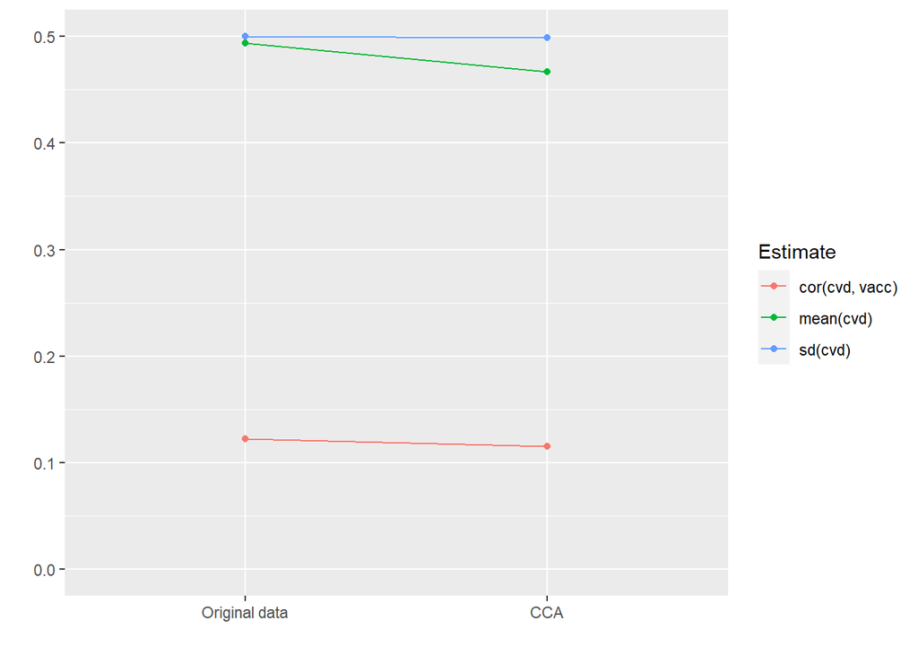

**Question 4.** What is the adjusted odds ratio for `vacc`, and the corresponding 95% confidence interval? Is annual influenza vaccination effective in reducing the risk of hospitalisation?

*Answer: The adjusted odds ratio is 0.19 with a 95% confidence interval ranging from 0.07 to 0.49. Annual influenza vaccination appears effective.*

**Question 5.** Does the CCA approach yield unbiased estimates for the regression coefficients and corresponding standard errors?

*Answer: If CVD values are MCAR, the CCA approach will yield unbiased estimates for the regression coefficients and standard errors. However, due to the exclusion of many participants, estimates will be very imprecise.*

### B. Drop covariates

Rather than omitting participants with missing values, it is possible to omit covariates with one or more missing values. Since we only have missing data for `cvd`, we can omit this variable from the statistical analysis and use all 40000 participants for estimating the adjusted odds ratio of influenza vaccination.

```r
dropmodel <- glm(hosp ~ vacc + DM + pulm + I(log(contact)) + age + sex, data = miss.data.uni, family = binomial())
dropmodel
```

```
##
## Call:  glm(formula = hosp ~ vacc + DM + pulm + I(log(contact)) + age +
##     sex, family = binomial(), data = miss.data.uni)
##
## Coefficients:
##     (Intercept)             vacc               DM             pulm
##       -11.40001         -0.40118          0.41453          0.51306
## I(log(contact))              age              sex
##         0.53546          0.07151         -0.77232
##
## Degrees of Freedom: 39999 Total (i.e. Null);  39993 Residual
## Null Deviance:       3077
## Residual Deviance: 2899  AIC: 2913
```

```r
results.vacc["Drop", ] <- c(coef(dropmodel)["vacc"], coef(summary(dropmodel))["vacc", "Std. Error"])
```

**Question 6.** What is a key problem of aformentioned approach?

*Answer: we no longer adjust our analysis for a key confounder, thereby potentially introducing bias in the adjusted odds ratio of influenza vaccination.*

### C. Mean imputation

Another common approach is to replace each missing value by the mean of their observed values. This approach results in an imputed dataset, here denoted as `mean.imputed.data`:

```r
mean.imputed.data <- miss.data.uni
mean.imputed.data$cvd[miss.cvd] <- mean(miss.data.uni$cvd, na.rm = TRUE)
summary(mean.imputed.data)
```

```
##       vacc             age              sex              cvd
##  Min.   :0.0000   Min.   : 65.00   Min.   :0.0000   Min.   :0.0000
##  1st Qu.:0.0000   1st Qu.: 70.00   1st Qu.:0.0000   1st Qu.:0.0000
##  Median :1.0000   Median : 75.00   Median :1.0000   Median :0.4666
##  Mean   :0.7404   Mean   : 75.65   Mean   :0.6191   Mean   :0.4666
##  3rd Qu.:1.0000   3rd Qu.: 80.00   3rd Qu.:1.0000   3rd Qu.:1.0000
##  Max.   :1.0000   Max.   :104.00   Max.   :1.0000   Max.   :1.0000
##       pulm              DM             contact            hosp
##  Min.   :0.0000   Min.   :0.00000   Min.   :  2.00   Min.   :0.00000
##  1st Qu.:0.0000   1st Qu.:0.00000   1st Qu.:  7.00   1st Qu.:0.00000
##  Median :0.0000   Median :0.00000   Median : 12.00   Median :0.00000
##  Mean   :0.1234   Mean   :0.06545   Mean   : 14.75   Mean   :0.00635
##  3rd Qu.:0.0000   3rd Qu.:0.00000   3rd Qu.: 20.00   3rd Qu.:0.00000
##  Max.   :1.0000   Max.   :1.00000   Max.   :146.00   Max.   :1.00000
```

**Question 7.** How does mean imputation affect the mean of the imputed variable `cvd`?

```r
mean(miss.data.uni$cvd, na.rm = TRUE) # Results from CCA
```

```
## [1] 0.4665806
```

```r
mean(mean.imputed.data$cvd) # Results from mean imputation
```

```
## [1] 0.4665806
```

**Question 8.** How does mean imputation affect the standard deviation of the imputed variable `cvd`?

```r
sd(miss.data.uni$cvd, na.rm = TRUE) # Results from CCA
```

```
## [1] 0.4988902
```

```r
sd(mean.imputed.data$cvd) # Results from mean imputation
```

```
## [1] 0.4335378
```

**Question 9.** How does mean imputation affect the correlation between the imputed variable `cvd` and the treatment `vacc`?

```r
cor(miss.data.uni, use = "complete.obs")["cvd", "vacc"]
```

```
## [1] 0.1157525
```

```r
cor(mean.imputed.data)["cvd", "vacc"]
```

```
## [1] 0.1048176
```

*Answer: The means are unchanged, as the imputed value is equal to the mean. The standard deviations are now smaller, as all imputed values lie at zero distance to the mean. The correlations have become weaker, as the imputed values do not covary with other variables.*

A summary is given below:

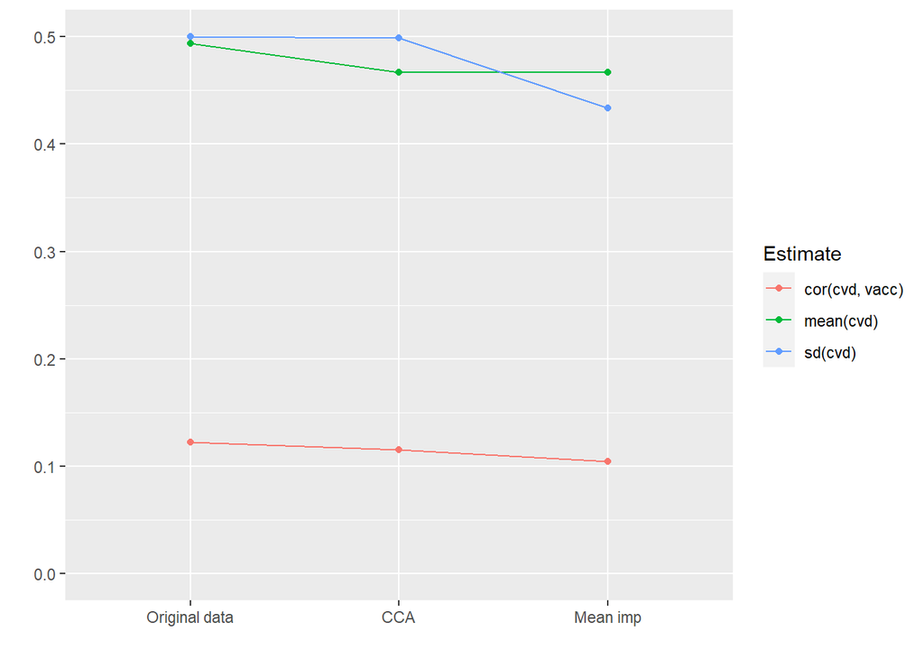

**Question 10.** Estimate the adjusted odds ratio for influenza vaccination in the imputed data. Do you expect

- an unbiased estimate of the effect of vaccination?
- an unbiased estimate of the error of the effect of vaccination?

*Answer: No, the associations are distorted. The standard error is irrelevant, because the estimate is biased.*

```r
meanmodel <- glm(Formula, data = mean.imputed.data, family = binomial())
meanmodel
```

```
##
## Call:  glm(formula = Formula, family = binomial(), data = mean.imputed.data)
##
## Coefficients:
##     (Intercept)             vacc               DM              cvd
##       -11.39068         -0.38769          0.40083         -0.38163
##            pulm  I(log(contact))              age              sex
##         0.49375          0.59138          0.07191         -0.78748
##
## Degrees of Freedom: 39999 Total (i.e. Null);  39992 Residual
## Null Deviance:       3077
## Residual Deviance: 2893  AIC: 2909
```

```r
results.vacc["Mean imputation", ] <- c(coef(meanmodel)["vacc"],
                                       coef(summary(meanmodel))["vacc", "Std. Error"])
```

## Regression

As demonstrated in the previous exercises, all of the aforementioned approaches are problematic in clinical practice. Complete case analysis is only valid when data are MCAR, but even then may be ineffective because information from many participants is ignored. Alternatively, when covariates with missing values are dropped from the analysis model, adjustment for corresponding confounders is no longer possible (which may again lead to bias). Finally, when replacing missing values by their observed mean, we ignore (and therefore distort) their potential relation with other variables. One approach to account for this correlation is to generate subject-specific imputations, rather than imputing the same value for all subjects. This approach requires the development of a so-called prediction model, which can be developed using the complete data at hand. As `cvd` represents a binary variable, we can use logistic regression analysis to generate predictions for the missing values. The dependent variable is then `cvd`, and the independent variables are all remaining variables including the outcome `hosp`.

In the following four methods, we will add increasing layers of complexity, to model the data more adequately. Note that the mean imputation we performed earlier is equivalent to an intercept-only regression model.

### D. Predict

As a first attempt, we can simply impute missing values with their predicted value, conditional on the observed values. The model to produce these predicted values conditional on the other variables is:

```r
imp.outcome <- "cvd"
imp.predictors <- "hosp + vacc + DM + pulm + I(log(contact)) + age + sex"
imp.formula <- formula(paste(imp.outcome, "~", imp.predictors) )
impmodel1   <- glm(imp.formula, data = miss.data.uni, family = binomial())
```

For binary variables, this predicted value represents a probability (`type = "response"`). Imputed values can then be generated as follows:

```r
regression1.data <- miss.data.uni
regression1.data$cvd[miss.cvd] <- prob.cvd2 <- predict(impmodel1, newdata = miss.data.uni[miss.cvd, ], type = "response")
```

We can now inspect the original and imputed values of `cvd` (which are the ones that differ from 0 or 1):

```r
cvd.data <- data.frame(cvd.original = miss.data.uni$cvd, cvd.imputed = regression1.data$cvd)
head(cvd.data)
```

```
##   cvd.original cvd.imputed
## 1           NA   0.6613724
## 2            1   1.0000000
## 3            1   1.0000000
## 4            1   1.0000000
## 5            1   1.0000000
## 6            1   1.0000000
```

**Question 11.** How does imputation affect the mean, the standard deviation and the correlation of the imputed variable `cvd`?

```r
mean(regression1.data$cvd)
sd(regression1.data$cvd)
cor(regression1.data)["cvd", "vacc"]
```

[output not shown]

An overview of the distribution for `cvd` is given below:

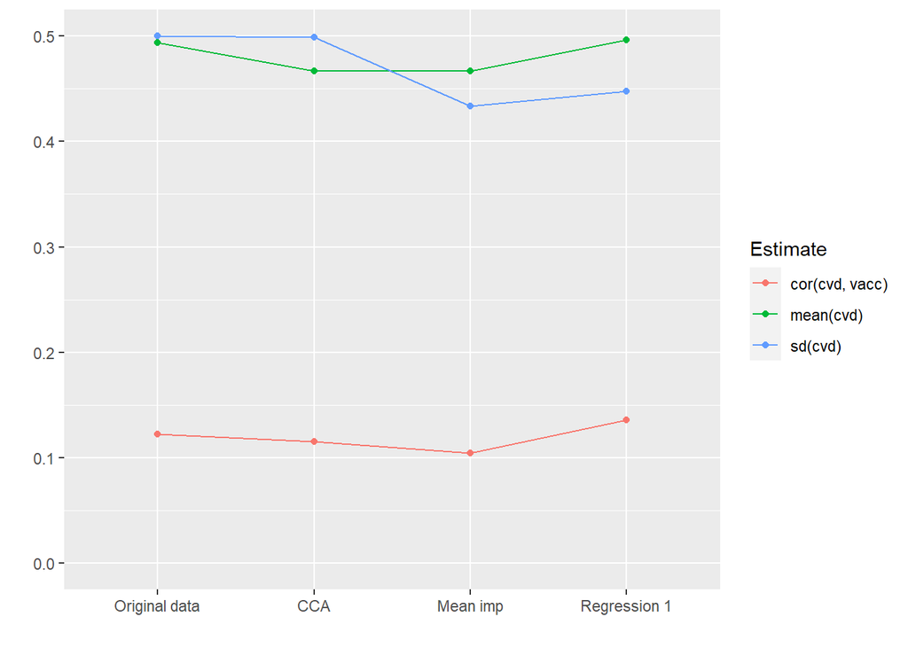

*Answer: The standard deviation of imputed variables are still too small. Conversely, the correlations have substantially increased and the means no longer fully correspond.*

We can now estimate the effect of influenza vaccination:

```r
regression1model <- glm(Formula, data = regression1.data, family = binomial())
regression1model
```

```
##
## Call:  glm(formula = Formula, family = binomial(), data = regression1.data)
##
## Coefficients:
##     (Intercept)             vacc               DM              cvd
##       -11.28140         -0.42107          0.40633          0.41113
##            pulm  I(log(contact))              age              sex
##         0.53278          0.44292          0.07001         -0.75569
##
## Degrees of Freedom: 39999 Total (i.e. Null);  39992 Residual
## Null Deviance:       3077
## Residual Deviance: 2893  AIC: 2909
```

```r
results.vacc["Regression 1", ] <- c(coef(regression1model)["vacc"],
                                    coef(summary(regression1model))["vacc", "Std. Error"])
```

**Question 12.** Do you think this approach yields valid estimates for the effect of influenza vaccination?

*When observations are only missing for one variable, this method could produce valid estimates for the regression coefficients. However, uncertainty in imputed values is completely ignored. For instance, in reality we rarely observe the ‘expected’ values due to random variation. Ignoring this uncertainty may lead to standard errors that are too small.*

It may be clear that the prediction that is used for imputation may still differ from the actual (unknown) value. Predicted values, however, do not portray this uncertainty, and may therefore distort subsequent analyses.

### E. Predict + noise

We can improve upon the prediction method by adding an appropriate amount of random noise to the predicted value (van Buuren 2012). For binary outcomes, we can add model-based noise by generating the imputed value from a binomial distribution of one ‘trial’ (`size = 1`), conditional on covariates:

```r
N <- sum(miss.cvd) # Number of missing cvd
regression2.data <- miss.data.uni
regression2.data$cvd[miss.cvd] <- rbinom(n = N, size = 1, prob = prob.cvd2)
```

We can inspect the original and imputed values of `cvd`. Note that imputations now correspond to binary variables, similar to the oberved ones:

```r
cvd.data <- data.frame(cvd.original = miss.data.uni$cvd, cvd.imputed1 = regression1.data$cvd, cvd.imputed2 = regression2.data$cvd)
head(cvd.data)
```

```
##   cvd.original cvd.imputed1 cvd.imputed2
## 1           NA    0.6613724            0
## 2            1    1.0000000            1
## 3            1    1.0000000            1
## 4            1    1.0000000            1
## 5            1    1.0000000            1
## 6            1    1.0000000            1
```

**Question 13.** How does imputation affect the mean, the standard deviation and the correlation of the imputed variable `cvd`?

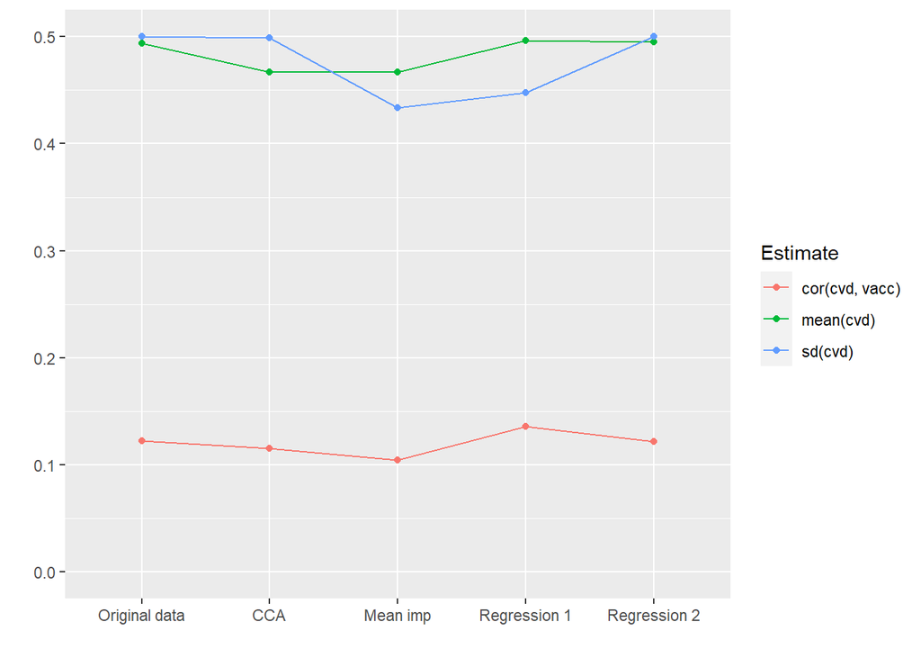

*Answer: The distribution for the imputed variable cvd is now fairly similar to the distriution in the original data.*

Again, we can estimate the effect of influenza vaccination:

```r
regression2model <- glm(Formula, data = regression2.data, family = binomial())
regression2model
```

```
##
## Call:  glm(formula = Formula, family = binomial(), data = regression2.data)
##
## Coefficients:
##     (Intercept)             vacc               DM              cvd
##       -11.32948         -0.41284          0.40772          0.20414
##            pulm  I(log(contact))              age              sex
##         0.52101          0.48847          0.07072         -0.76585
##
## Degrees of Freedom: 39999 Total (i.e. Null);  39992 Residual
## Null Deviance:       3077
## Residual Deviance: 2897  AIC: 2913
```

```r
results.vacc["Regression 2", ] <- c(coef(regression2model)["vacc"], coef(summary(regression2model))["vacc", "Std. Error"])
```

It may be clear that regression method 2 already works quite well. In practice, however, the predict + noise method may become problematic when sample sizes are relatively small and for this reason more advanced imputation methods are preferred. We therefore consider 2 important extensions below.

### F. Predict + noise + parameter uncertainty

Adding noise is a major step forward, but not quite right. The method in the previous section requires that the intercept and slope of the imputation model `impmodel1` are known. However, the values of these parameters are estimated from the data at hand, and are particularly uncertain when sample sizes are relatively small. Hence, we can further improve our imputations as follows. Rather that directly using the estimated regression coefficients for generating predicted values for `cvd`, we can add variability in these coefficients by relating to their standard error.

For each patient, generate a random draw of regression coefficients from the multivariate Student-t distribution (`rmt()` from the `mnormt` package). Ideally, we only need to do this for patients with missing values (denoted by `miss.cvd`). As we want to incorporate the uncertainty of the coefficients into the predictions, we cannot simply use `predict(imp.model1)` anymore. We will have to code it ourselves, as follows.

We start with drawing coefficients from a multivariate Student-$t$ distribution:

```r
beta.i3 <- rmt(N, mean=impmodel1$coef, S=vcov(impmodel1), df=impmodel1$df.residual)
```

Hence, the coefficients that will be used for generating imputations now vary from subject to subject:

```r
head(beta.i3)
```

```
##      (Intercept)        hosp      vacc         DM       pulm I(log(contact))
## [1,]   -4.725494  0.17100233 0.2120801 0.18089468 -0.3017354        1.191681
## [2,]   -5.045932  1.01694785 0.1986733 0.11010063 -0.2129187        1.196672
## [3,]   -4.984705  0.37999586 0.1628981 0.22461019 -0.2188579        1.174547
## [4,]   -4.857780  0.62231258 0.2392097 0.03761786 -0.3755124        1.199592
## [5,]   -5.085356  0.02130022 0.2284791 0.17889948 -0.2514179        1.175979
## [6,]   -4.635023 -0.75790687 0.2164264 0.21831703 -0.2686285        1.173838
##             age        sex
## [1,] 0.02464967 -0.2895740
## [2,] 0.02887311 -0.2285468
## [3,] 0.02843770 -0.2428435
## [4,] 0.02595537 -0.2942881
## [5,] 0.02930750 -0.2598987
## [6,] 0.02276360 -0.1623806
```

Now we have to structure our data with missing `cvd` observations, so that we can apply our regression coefficients afterwards to calculate the individual predictions. The `predict()` function does this behind the scenes, but can no longer be used here as we are changing the regression coefficients. Hence, we will use the `model.matrix()` function to prepare the data:

```r
r3.pred.data <- model.matrix(formula(paste("~", imp.predictors)), data=miss.data.uni[miss.cvd,])
head(r3.pred.data)
```

```
##    (Intercept) hosp vacc DM pulm I(log(contact)) age sex
## 1            1    0    1  0    1        3.295837  66   0
## 8            1    0    1  0    0        2.833213  81   1
## 14           1    0    0  0    0        3.555348  67   0
## 17           1    0    1  0    0        2.302585  68   1
## 21           1    0    1  0    0        2.639057  68   0
## 24           1    1    1  0    0        2.995732  72   0
```

Now that we have our data, we can calulate the linear predictors and use the inverse logit to produce the probabilities of `cvd`.

```r
prob.cvd3 <- rep(NA, N)
for (i in 1:N) {
  prob.cvd3[i] <- 1/(1+exp(-r3.pred.data[i,] %*% beta.i3[i,]))
}
```

And finally, we again draw `cvd` from a binomial distribution to account for sampling variation:

```r
regression3.data <- miss.data.uni
regression3.data$cvd[miss.cvd] <- rbinom(n = N, size = 1, prob = prob.cvd3)
```

Again, we can inspect the original and imputed values of `cvd`:

```r
cvd.data <- data.frame(cvd.original = miss.data.uni$cvd, cvd.imputed1 = regression1.data$cvd, cvd.imputed2 = regression2.data$cvd, cvd.imputed3 = regression3.data$cvd)
head(cvd.data)
```

```
##   cvd.original cvd.imputed1 cvd.imputed2 cvd.imputed3
## 1           NA    0.6613724            0            0
## 2            1    1.0000000            1            1
## 3            1    1.0000000            1            1
## 4            1    1.0000000            1            1
## 5            1    1.0000000            1            1
## 6            1    1.0000000            1            1
```

The resulting distribution for `cvd` is given below:

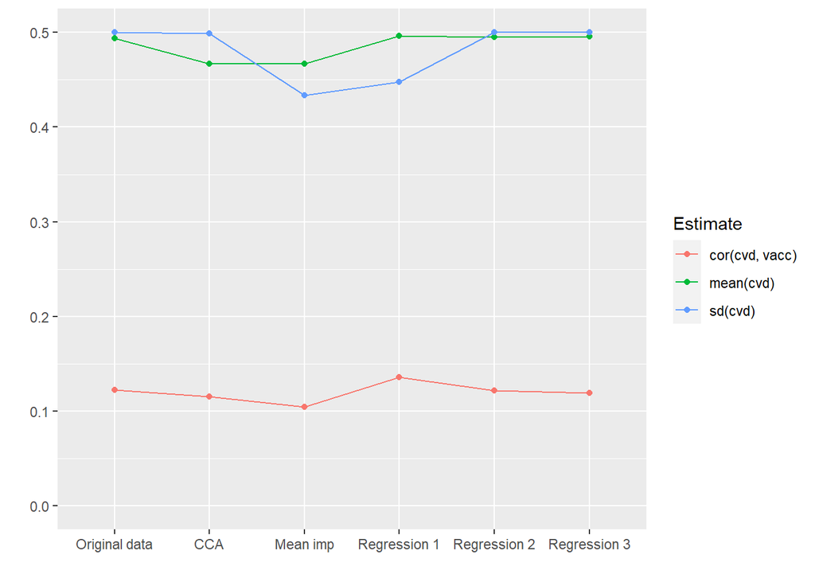

Again, we use the imputed data to estimate the effect for influenza vaccination:

```r
regression3model <- glm(Formula, data = regression3.data, family = binomial())
regression3model
```

```
##
## Call:  glm(formula = Formula, family = binomial(), data = regression3.data)
##
## Coefficients:
##     (Intercept)             vacc               DM              cvd
##       -11.30157         -0.41896          0.40635          0.34894
##            pulm  I(log(contact))              age              sex
##         0.52656          0.45677          0.07028         -0.75884
##
## Degrees of Freedom: 39999 Total (i.e. Null);  39992 Residual
## Null Deviance:       3077
## Residual Deviance: 2893  AIC: 2909
```

```r
results.vacc["Regression 3", ] <- c(coef(regression3model)["vacc"], coef(summary(regression3model))["vacc", "Std. Error"])
```

### G. Multiple Imputation

So far, we have analyzed imputed datasets as if all their data were actually observed. It may be clear that this approach is problematic, as it ignores any uncertainty arising from imputation. Moreover, because the imputation methods based on regression imputed values through random sampling, the validity of imputations becomes highly dependent on *chance*. In order to preserve all uncertainty arising from imputation, we need to repeat the sampling procedures many times, and generate many imputed datasets. Then, values that can reliably be imputed will not vary much across imputed datasets, whereas other values that are difficult to impute will substantially vary across imputed datasets. This variation in imputations for a certain missing value can lead to differences in the analysis of imputed datasets, thereby reflecting to what extent our results (i.e. odds ratio of influenza vaccination) are affected by the presence of missing data.

Briefly, we can repeat the imputation procedure as follows:

```r
n.imp <- 50 # Number of predictions per patient.

results.vacc4 <- as.data.frame(matrix(NA, ncol = 5, nrow = n.imp)) # Save distribution of vacc for each imputed dataset
colnames(results.vacc4) <- c("mean", "sd", "cor", "beta.vacc", "se.vacc")

# Initialize full dataset
regression4.data <- miss.data.uni

# Initiatize data for which imputations are needed
r4.pred.data <- model.matrix(formula(paste("~", imp.predictors)), data=miss.data.uni[miss.cvd,])

# Multiple Imputation
for (j in 1:n.imp) {
  beta.i4 <- rmt(N, mean=impmodel1$coef, S=vcov(impmodel1), df=impmodel1$df.residual)
  prob.cvd4 <- rep(NA, N)
  for (i in 1:N) {
    prob.cvd4[i] <- 1/(1+exp(-r4.pred.data[i,] %*% beta.i4[i,]))
  }

  regression4.data$cvd[miss.cvd] <- rbinom(n = N, size = 1, prob = prob.cvd4)
  regression4model   <- glm(Formula, data = regression4.data, family = binomial())

  # Save the results
  results.vacc4$mean[j] <- mean(regression4.data$cvd)
  results.vacc4$sd[j] <- sd(regression4.data$cvd)
  results.vacc4$cor[j] <- cor(regression4.data)["cvd", "vacc"]
  results.vacc4$beta.vacc[j] <- coef(regression4model)["vacc"]
  results.vacc4$se.vacc[j]    <- coef(summary(regression4model))["vacc", "Std. Error"]
}
```

```r
print(results.vacc4)
```

```
##        mean        sd       cor  beta.vacc   se.vacc
## 1  0.495925 0.4999896 0.1199457 -0.4163196 0.1447494
## 2  0.496850 0.4999963 0.1227503 -0.4094568 0.1446862
## 3  0.496825 0.4999962 0.1234050 -0.4115783 0.1447351
## 4  0.497000 0.4999972 0.1208748 -0.4069121 0.1446809
## 5  0.497175 0.4999983 0.1222223 -0.4083041 0.1446668
## 6  0.495825 0.4999888 0.1214242 -0.4161629 0.1447423
## 7  0.496675 0.4999952 0.1231136 -0.4235595 0.1448584
## 8  0.497300 0.4999990 0.1232826 -0.4150471 0.1448290
## 9  0.496150 0.4999914 0.1237473 -0.4193947 0.1447851
## 10 0.495800 0.4999886 0.1215087 -0.4154609 0.1447345
## 11 0.497125 0.4999980 0.1215929 -0.4075022 0.1447048
## 12 0.493975 0.4999699 0.1214048 -0.4140857 0.1447581
## 13 0.496825 0.4999962 0.1244315 -0.4150459 0.1447654
## 14 0.496750 0.4999957 0.1220618 -0.4160421 0.1447450
```

[output cut: 36 more lines]

Although it is helpful to present results separately for each imputed dataset, this is often impractical. For this reason, Rubin has proposed some rules to combine the results across datasets. For simple statistics such as the mean or standard deviation, we can simply take the average:

```r
apply(results.vacc4[,c("mean", "sd", "cor", "beta.vacc")], 2, mean)
```

```
##       mean         sd        cor  beta.vacc
##  0.4965495  0.4999934  0.1216766 -0.4146575
```

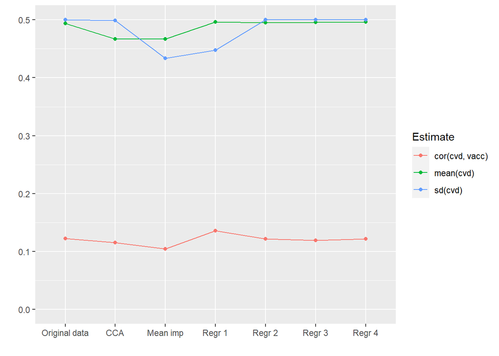

More technically, suppose that $\hat Q_l$ is the estimate of the $l^{\mbox{th}}$ repeated imputation, then the combined estimate is equal to

$$\bar Q = \frac{1}{m} \sum_{l=1}^{m} \hat Q_l$$
To calculate the standard error of the pooled estimates, we need to account for variation within and between the imputed datasets. In other words, it is not sufficient to take the average of `results.vacc4$se.vacc` to obtain the standard error of the pooled regression coefficient for `vacc`. Instead, the total error variance of $\bar Q$ is given as:

$$T = \bar U + \left( 1 + \frac{1}{m} \right) B$$

where $m$ is the amount of generated imputations (i.e. `n.imp`). Further, we have:

$$\bar U = \frac{1}{m} \sum_{l=1}^{m} \bar U_l$$
where the square root of $\bar U_l$ denotes the complete-data standard errors `results.vacc4$se.vacc`. Finally, we have:

$$B = \frac{1}{m-1} \sum_{l=1}^{m} (\hat Q_l - \bar Q)^2$$

The standard error for the pooled regression coefficient for `vacc` is thus given as:

```r
Qbar <- mean(results.vacc4$beta.vacc)
U <- sum(results.vacc4$se.vacc**2)/n.imp
B <- sum((results.vacc4$beta.vacc - Qbar)**2)/(n.imp-1)
se.beta.vacc <- sqrt(U + (1+1/n.imp)*B)
se.beta.vacc
```

```
## [1] 0.1448822
```

```r
# Store results
results.vacc["Regression 4", ] <- c(Qbar, se.beta.vacc)
```

### H. Multiple Imputation in mice()

We can directly apply all of the aforementioned steps via the $mice()$ package:

```r
data.mice <- model.frame(formula(paste("~ 0 + ", imp.predictors, "+", imp.outcome)), data = miss.data.uni, na.action = 'na.pass')
data.mice$cvd <- as.factor(data.mice$cvd)
colnames(data.mice)[5] <- "logContact"
head(data.mice)
```

```
##   hosp vacc DM pulm   logContact age sex  cvd
## 1    0    1  0    1 3.295836....  66   0 <NA>
## 2    0    1  0    0 1.386294....  73   1    1
## 3    0    1  0    0 2.079441....  75   1    1
## 4    0    1  0    0 1.945910....  76   1    1
## 5    0    1  0    0 1.945910....  77   1    1
## 6    0    1  0    0 1.609437....  78   1    1
```

```r
# Initialize Imputation Model
setup.imp <- mice(data.mice, maxit=0)

# Lets ensure logistic regression is used for imputation
setup.imp$method["cvd"] <- "logreg"

# Start the imputation. No Gibbs sampler is needed (hence maxit=1)
dat.imp <- mice(data.mice, method = setup.imp$method, m = n.imp, maxit = 1, printFlag = F)

# Start the analyses
regression5model <- with(data=dat.imp, exp=glm(hosp ~ vacc + DM + cvd + pulm + logContact + age + sex, family = binomial()))

# Use Rubin's rules
pooledEst <- pool(regression5model)

# Store results
results.vacc["Regression 5", ] <- c(pooledEst$pooled$estimate[2], sqrt(pooledEst$pooled$t[2]))
```

## Comparison

For comparison, we will now analyze the original data where no missing values were presen. We can then compare the coefficients and standard errors of our models to what we would have obtained if we had had the full data. First we load and inspect the full data:

```r
load("full.data.RData")
```

And apply the logistic model:

```r
fullmodel <- glm(Formula, data = FULL.data, family = binomial())
results.vacc["Original data", ] <- c(coef(fullmodel)["vacc"], coef(summary(fullmodel))["vacc", "Std. Error"])
```

**Question 14.** For which method are the obtained parameter estimates closest to estimates of the full data model?

```r
results.vacc
```

```
##                          b        se
## CCA             -1.6821152 0.4929982
## Drop            -0.4011813 0.1444709
## Mean imputation -0.3876875 0.1446818
## Regression 1    -0.4210747 0.1447589
## Regression 2    -0.4128386 0.1447509
## Regression 3    -0.4189637 0.1447335
## Regression 4    -0.4146575 0.1448822
## Regression 5    -0.4132052 0.1466849
## Original data   -0.4347318 0.1448477
```

Or use the following function to compute the percentage difference between the estimates obtained with the different strategies, and the estimates obtained on the full data:

```r
PCT.diff <- function(x, ref = ncol(x))
{
  x <- t(as.matrix(x))
  y <- round(t(((x[ , -ref] - x[ , ref]) / x[, ref])[, -ref] * 100), 2)
  y[ , ] <- paste(y, "%", sep = "")
  noquote(y)
}

PCT.diff(results.vacc)
```

```
##                 b       se
## CCA             286.93% 240.36%
## Drop            -7.72%  -0.26%
## Mean imputation -10.82% -0.11%
## Regression 1    -3.14%  -0.06%
## Regression 2    -5.04%  -0.07%
## Regression 3    -3.63%  -0.08%
## Regression 4    -4.62%  0.02%
## Regression 5    -4.95%  1.27%
```

## References

Buuren, Stef van. 2012. *Flexible Imputation of Missing Data*. Chapman & Hall/Crc Interdisciplinary Statistics Series. Boca Raton, Fla.: CRC Press.